# London_model_simulation

Tianyi Chen

2025-01-28

## Setup

In this simulation i will compare the localizer $\hat{t}$’s performance by using different metrics to construct distance matrix and then apply CMDS and only use the first dimension. Now we have 4 metrics: $W_1$, $W_2$, $d_{MV}$ with true 1-1 correspondence, and just use square root of average degree as representation of the TSG. After we get 4 mirrors/representation, i apply $l_{\infty}$ localizer to get $\hat{t}$ and then MSE = $\left(\frac{\hat{t} - t^*}{m}\right)^2$.

Last week I showed a result that is confusing, which is not reproducible and meaningless, since there was a bug. After i fixed the bug, something similarly disturbing showed up again, which you will see in the figure: using $d_{MV}$ with true 1-1, the MSE increase as $m$ increases when $n=200$. This doesn’t have a good explanation, since we know as $m$ increases, the $d_{MV}$’s 1st dim is more linear as London model is asymptotically Euclidean 1-d piecewise linear. We also conjecture(in our paper) for fixed $n$,i.e fixed variance, as $m$ increases, we should still be able to learn the piecewise linear and consistently estimate the changepoint.

## My explanation

What i found is this conjecture is not invalidated, and the problem is not the $d_{MV}$ but the $l_{\infty}$ localizer, it is **too sensitive** to the outlier, and when n is small, the variance is big, and when m is large, the outlier turns to appear more often at the boundary point, and this cause the $l_{\infty}$ localizer to localize $\hat{t}$ often near the boundary, causing MSE big. This can be observed from the histograms later. Also here is an illustration i found from simulations:

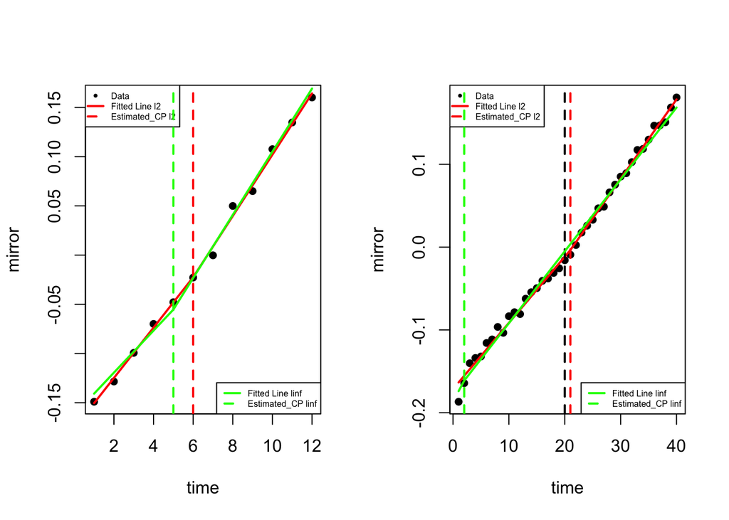

```r
par(mfrow = c(1,2))

m = tmax = length(example_df.mds_dMV_m_12)
a = find_slope_changepoint_with_plot(example_df.mds_dMV_m_12, doplot = T)
ecp_l1 <-  linf_error(example_df.mds_dMV_m_12)[2]
abline(v = ecp_l1, col='green' ,lwd = 2, lty = 2)
res <- linf_cp(1:tmax, example_df.mds_dMV_m_12 , ecp_l1)
t = 1:tmax
y_fit = res[2] + res[3] * (t -  ecp_l1) +
  (res[4] - res[3]) * (t -  ecp_l1) * (t >  ecp_l1)
lines(1:tmax, y_fit, col = 'green' , lwd = 2)
legend("bottomright", legend = c("Fitted Line linf", "Estimated_CP linf"),
       col = c( "green", "green"), lty = c( 1, 2), lwd = 2, cex =0.5)

m = tmax = length(example_df.mds_dMV_m_40)
b = find_slope_changepoint_with_plot(example_df.mds_dMV_m_40, doplot = T)
ecp_l1 = linf_error(example_df.mds_dMV_m_40)[2]
abline(v = ecp_l1, col='green' ,lwd = 2, lty = 2)
res <- linf_cp(1:tmax, example_df.mds_dMV_m_40 , ecp_l1)
t = 1:tmax
y_fit = res[2] + res[3] * (t -  ecp_l1) +
  (res[4] - res[3]) * (t -  ecp_l1) * (t >  ecp_l1)

lines(1:tmax, y_fit, col = 'green' , lwd = 2)
legend("bottomright", legend = c("Fitted Line linf", "Estimated_CP linf"),
       col = c( "green", "green"), lty = c( 1, 2), lwd = 2, cex=0.5)
```

Thus i implement, as we always wanted, the $l_2$ localizer ,which is:
$$\hat{t},\hat{\alpha},\hat{\beta}_L,\hat{\beta}_R=\underset{\substack{t'\in\mathcal{T}\\
\alpha, \beta_L, \beta_R, \beta_L\neq \beta_R}}{\mathrm{argmin}}
\sum_{t \in \mathcal{T} } \left( \alpha +
\beta_L(t-t')+(\beta_R-\beta_L)(t-t')I_{\{t > t'\}} -
\hat{\psi}(t) \right)^2.$$
And as shown in the figure, now using $d_{MV}$ metric still works ans as $m$ increases, MSE decreases. **However, the question that why $d_{MV}$ has such large variance and so noisy is still mysterious.**

```r
pacman::p_load(segmented, igraph, RSpectra, locfit, tidyverse, doParallel, broom, vegan, Matrix)
library(igraph)
library(iGraphMatch)
library(ggrepel)
pacman::p_load("doParallel")
registerDoParallel(detectCores()-1)
```

## Simulation with n= 200

```r
set.seed(2)
n = 200
p <- 0.3
q <- 0.4
nmc = 500

# Define the values of mm
mm <- c(12, 20, 30, 40)

# Initialize a list to store the results
list_name_l2 <- paste0("results_list_l2", "_n_",n)
assign(list_name_l2, list())

list_name <- paste0("results_list", "_n_",n)
assign(list_name, list())
# Define error types
error_types_l2 <- c("error_avg_degree_l2", "error_W1_l2", "error_W2_l2", "error_dMV_l2")
error_types <- c("error_avg_degree", "error_W1", "error_W2", "error_dMV")

# Loop over each value of m in mm
for (i in 1:length(mm)) {
  tmax <- m <- mm[i]
  tstar <- tmax / 2
  delta <- (1-0.1)/tmax
  # Dynamically create and assign a matrix
  matrix_name_l2 <- paste0("error_matrix_l2_m_", m, "_n_",n)
  matrix_name <- paste0("error_matrix_m_", m, "_n_",n)

  assign(matrix_name_l2, matrix(nrow = 4, ncol = nmc))
  assign(matrix_name, matrix(nrow = 4, ncol = nmc))

  for (mc in 1:nmc) {
    df <- doSim_London(n, tmax, delta, p, q, tstar)

    # Compute square root of avg_edges
    sqrt_edges <- sqrt(unlist(df$avg_edges))

    # Compute distance matrices
    Dhat_W1 <- getD_W1(df$xhat)
    Dhat_W2 <- getD_W2(df$xhat)
    D_dMV  <- getD(df$xhat)

    # Perform MDS
    df.mds_W1 <- doMDS(Dhat_W1, doplot = FALSE)
    df.mds_W2 <- doMDS(Dhat_W2, doplot = FALSE)
    df.mds_dMV <- doMDS(D_dMV, doplot = FALSE)

    # Calculate errors using l2
    error_avg_degree_l2 <- find_slope_changepoint_with_plot(sqrt_edges, doplot = F)$error
    error_W1_l2 <- find_slope_changepoint_with_plot(df.mds_W1$mds[,1], doplot = F)$error
    error_W2_l2 <- find_slope_changepoint_with_plot(df.mds_W2$mds[,1], doplot = F)$error
    error_dMV_l2 <- find_slope_changepoint_with_plot(df.mds_dMV$mds[,1], doplot = F)$error

    error_avg_degree <- linf_error(sqrt_edges)[1]
    error_W1 <- linf_error(df.mds_W1$mds[,1])[1]
    error_W2 <- linf_error(df.mds_W2$mds[,1])[1]
    error_dMV <- linf_error(df.mds_dMV$mds[,1])[1]
    #print(error_dMV)

    # Retrieve and update the matrix dynamically
    temp_matrix_l2 <- get(matrix_name_l2)
    temp_matrix_l2[, mc] <- c(error_avg_degree_l2, error_W1_l2, error_W2_l2, error_dMV_l2)
    assign(matrix_name_l2, temp_matrix_l2)

    temp_matrix <- get(matrix_name)
    temp_matrix[, mc] <- c(error_avg_degree, error_W1, error_W2, error_dMV)
    assign(matrix_name, temp_matrix)


    if (mc %% 100 == 0) {
      print(c(i, mc))
    }
  }

  # Retrieve the updated matrix
  final_matrix <- get(matrix_name)

  # Compute mean squared error and confidence interval
  mse_mean <- apply(final_matrix^2, 1, mean)
  mse_sd <- apply(final_matrix^2, 1, sd)
  conf_interval <- 1.96 * mse_sd / sqrt(nmc)

  # Create a dataframe for the current m value
  temp_df <- data.frame(
    m = rep(m, 4),
    error_type = error_types,
    Lower_CI = mse_mean - conf_interval,
    Mean_MSE = mse_mean,
    Upper_CI = mse_mean + conf_interval
  )

  current_list <- get(list_name)
  current_list[[i]] <- temp_df

  assign(list_name, current_list)

  final_matrix_l2 <- get(matrix_name_l2)

  # Compute mean squared error and confidence interval
  mse_mean_l2 <- apply(final_matrix_l2^2, 1, mean)
  mse_sd_l2 <- apply(final_matrix_l2^2, 1, sd)
  conf_interval_l2 <- 1.96 * mse_sd_l2 / sqrt(nmc)

  # Create a dataframe for the current m value
  temp_df_l2 <- data.frame(
    m = rep(m, 4),
    error_type = error_types_l2,
    Lower_CI = mse_mean_l2 - conf_interval_l2,
    Mean_MSE = mse_mean_l2,
    Upper_CI = mse_mean_l2 + conf_interval_l2
  )
  current_list_l2 <- get(list_name_l2)
  current_list_l2[[i]] <- temp_df_l2
  assign(list_name_l2, current_list_l2)
}
summary_df_both <- do.call(rbind, c(get(list_name_l2), get(list_name)))
```

## Summary results shows that $L_2$ localizer performs much better than $l_{\infty}$ Localizer when $n$ small.

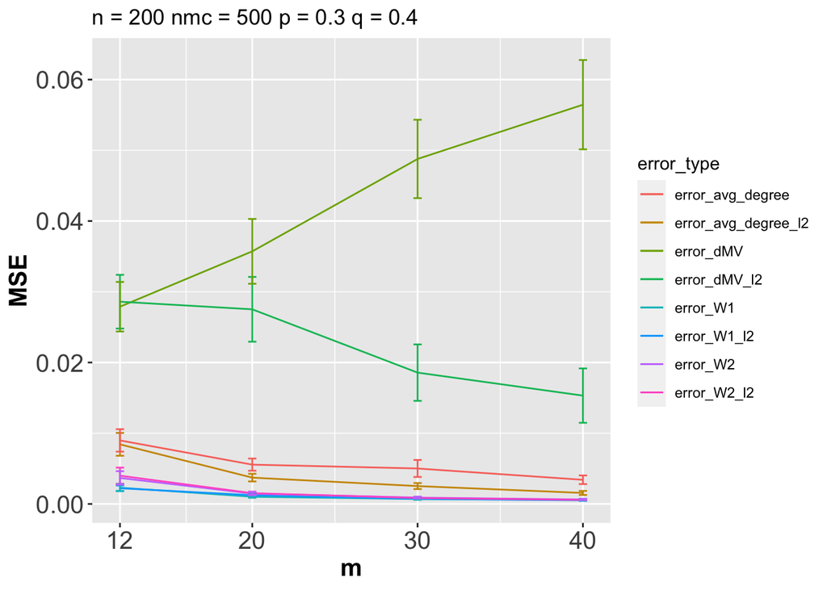

```r
plottt1 <- ggplot(summary_df_both , aes(x = m, y = Mean_MSE, color = error_type)) +
  geom_line() +
  geom_errorbar(aes(ymin = Lower_CI, ymax = Upper_CI), width = 0.5) +
  scale_x_continuous(breaks = mm) +
  labs(y = 'MSE', x = 'm', title =  paste('n =', n,
                                          'nmc =', nmc,
                                          'p =', p,
                                          'q =', q)) +
  theme(
    axis.text = element_text(size = 15),
    axis.title = element_text(size = 15, face = "bold")
  )

print(plottt1)
```

## results hists for $d_{MV}$ with $l_{\infty}$:

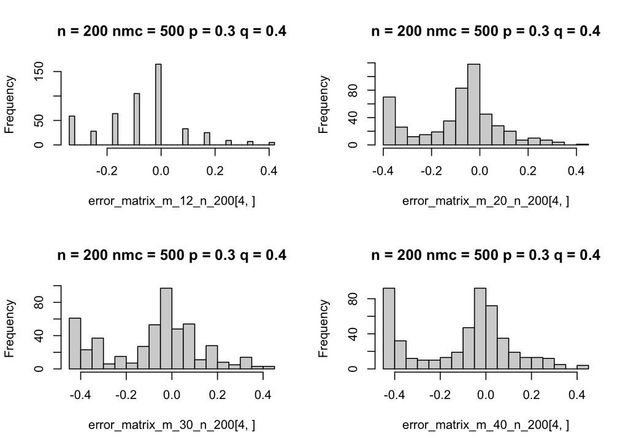

```r
par(mfrow = c(2,2))

hist(error_matrix_m_12_n_200[4, ], breaks = 30, main =  paste('n =', n,
                                          'nmc =', nmc,
                                          'p =', p,
                                          'q =', q))
hist(error_matrix_m_20_n_200[4, ], breaks = 30, main =  paste('n =', n,
                                          'nmc =', nmc,
                                          'p =', p,
                                          'q =', q))
hist(error_matrix_m_30_n_200[4, ], breaks = 30, main =  paste('n =', n,
                                          'nmc =', nmc,
                                          'p =', p,
                                          'q =', q))
hist(error_matrix_m_40_n_200[4, ], breaks = 30, main =  paste('n =', n,
                                          'nmc =', nmc,
                                          'p =', p,
                                          'q =', q))
```

These histograms again show as $m$ larger, using $l_{\infty}$ localizer keeps gets $\hat{t}$ at starting points, -0.4 has lots of mass.

## results hists for $d_{MV}$ with $l_{2}$

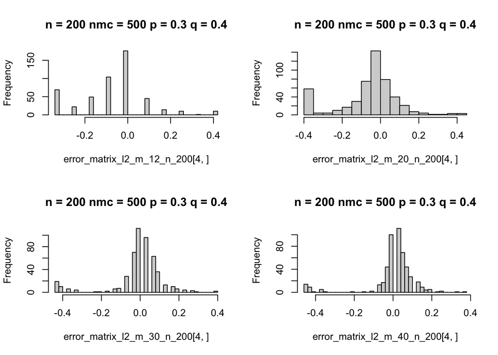

```r
par(mfrow = c(2,2))

hist(error_matrix_l2_m_12_n_200[4, ], breaks = 30, main =  paste('n =', n,
                                          'nmc =', nmc,
                                          'p =', p,
                                          'q =', q))
hist(error_matrix_l2_m_20_n_200[4, ], breaks = 30, main =  paste('n =', n,
                                          'nmc =', nmc,
                                          'p =', p,
                                          'q =', q))
hist(error_matrix_l2_m_30_n_200[4, ], breaks = 30, main =  paste('n =', n,
                                          'nmc =', nmc,
                                          'p =', p,
                                          'q =', q))
hist(error_matrix_l2_m_40_n_200[4, ], breaks = 30, main =  paste('n =', n,
                                          'nmc =', nmc,
                                          'p =', p,
                                          'q =', q))
```

While $l_2$ localzier doesn’t suffer from this.

## results hists for avg degree using $l_{\infty}$:

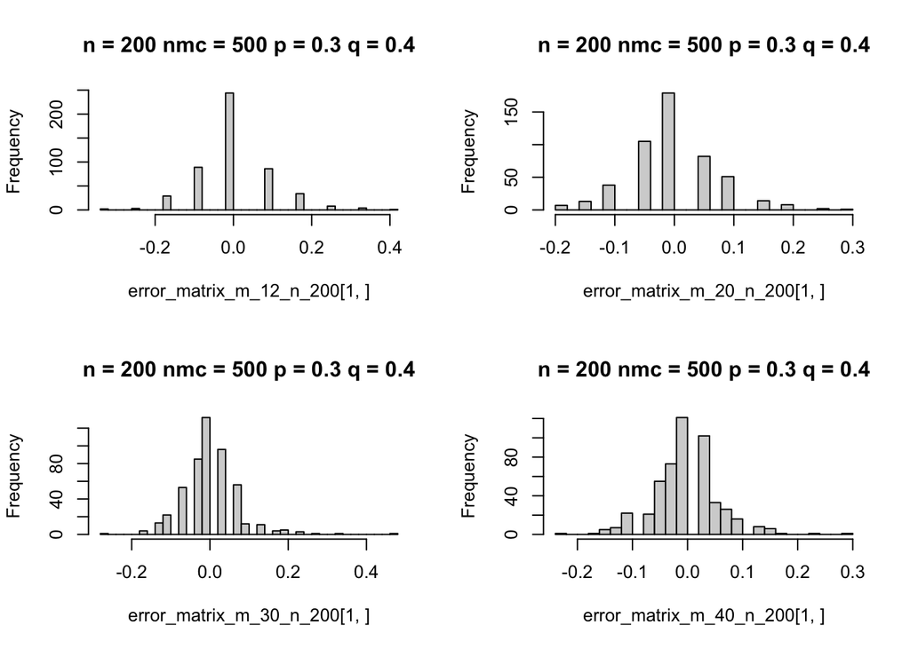

```r
par(mfrow = c(2,2))

hist(error_matrix_m_12_n_200[1, ], breaks = 30, main =  paste('n =', n,
                                          'nmc =', nmc,
                                          'p =', p,
                                          'q =', q))
hist(error_matrix_m_20_n_200[1, ], breaks = 30, main =  paste('n =', n,
                                          'nmc =', nmc,
                                          'p =', p,
                                          'q =', q))
hist(error_matrix_m_30_n_200[1, ], breaks = 30, main =  paste('n =', n,
                                          'nmc =', nmc,
                                          'p =', p,
                                          'q =', q))
hist(error_matrix_m_40_n_200[1, ], breaks = 30, main =  paste('n =', n,
                                          'nmc =', nmc,
                                          'p =', p,
                                          'q =', q))
```

## results hists for $W_1$ using $l_{\infty}$:

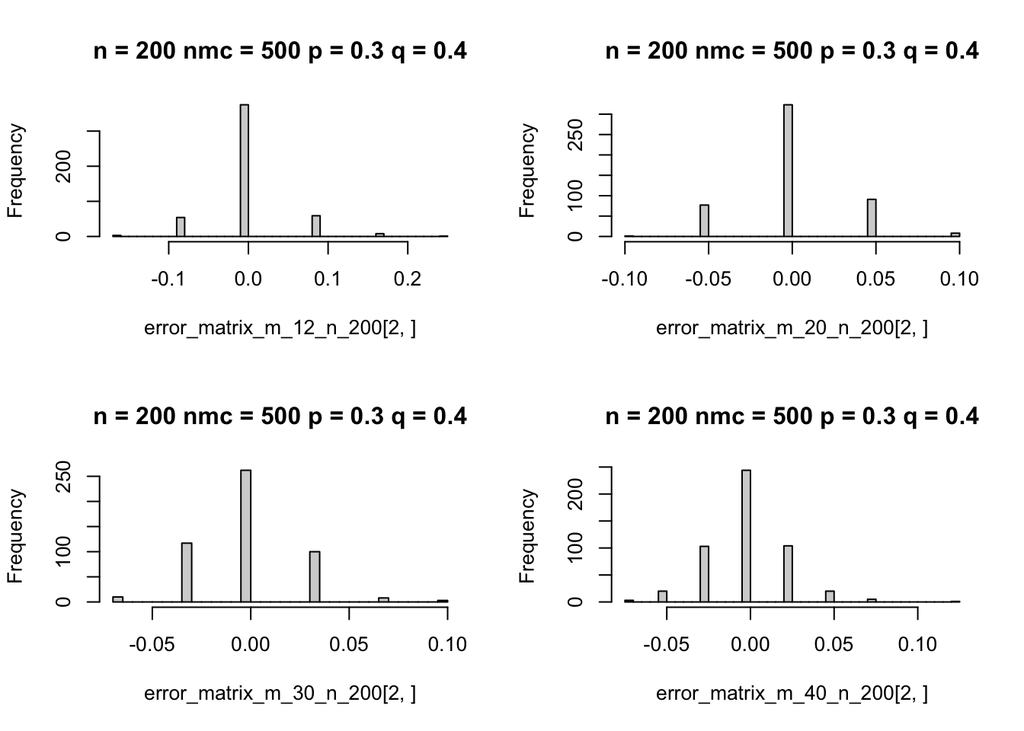

```r
par(mfrow = c(2,2))

hist(error_matrix_m_12_n_200[2, ], breaks = 30, main =  paste('n =', n,
                                          'nmc =', nmc,
                                          'p =', p,
                                          'q =', q))
hist(error_matrix_m_20_n_200[2, ], breaks = 30, main =  paste('n =', n,
                                          'nmc =', nmc,
                                          'p =', p,
                                          'q =', q))
hist(error_matrix_m_30_n_200[2, ], breaks = 30, main =  paste('n =', n,
                                          'nmc =', nmc,
                                          'p =', p,
                                          'q =', q))
hist(error_matrix_m_40_n_200[2, ], breaks = 30, main =  paste('n =', n,
                                          'nmc =', nmc,
                                          'p =', p,
                                          'q =', q))
```